# Optimal Treatment Analysis

## Outcome Variable

**Outcome Variable:** ever_wasted

## Predictor Variables

**Intervention Variable:** mhtcm

**Adjustment Set:**

- arm
- W_mage
- meducyrs
- feducyrs
- single
- delta_W_mage
- delta_meducyrs
- delta_feducyrs
- delta_single

## Stratifying Variables

The analysis was stratified on these variable(s):

- agecat
- studyid
- country

## Data Summary

| agecat | studyid | country | mhtcm | ever_wasted | n_cell | n |
| --- | --- | --- | --- | --- | --- | --- |
| 0-24 months | ki0047075b-MAL-ED | BANGLADESH | >=155 cm | 0 | 19 | 254 |
| 0-24 months | ki0047075b-MAL-ED | BANGLADESH | >=155 cm | 1 | 6 | 254 |
| 0-24 months | ki0047075b-MAL-ED | BANGLADESH | <151 cm | 0 | 104 | 254 |
| 0-24 months | ki0047075b-MAL-ED | BANGLADESH | <151 cm | 1 | 59 | 254 |
| 0-24 months | ki0047075b-MAL-ED | BANGLADESH | [151-155) cm | 0 | 46 | 254 |
| 0-24 months | ki0047075b-MAL-ED | BANGLADESH | [151-155) cm | 1 | 20 | 254 |
| 0-24 months | ki0047075b-MAL-ED | BRAZIL | >=155 cm | 0 | 116 | 222 |
| 0-24 months | ki0047075b-MAL-ED | BRAZIL | >=155 cm | 1 | 14 | 222 |
| 0-24 months | ki0047075b-MAL-ED | BRAZIL | <151 cm | 0 | 49 | 222 |
| 0-24 months | ki0047075b-MAL-ED | BRAZIL | <151 cm | 1 | 4 | 222 |
| 0-24 months | ki0047075b-MAL-ED | BRAZIL | [151-155) cm | 0 | 38 | 222 |
| 0-24 months | ki0047075b-MAL-ED | BRAZIL | [151-155) cm | 1 | 1 | 222 |
| 0-24 months | ki0047075b-MAL-ED | INDIA | >=155 cm | 0 | 31 | 242 |
| 0-24 months | ki0047075b-MAL-ED | INDIA | >=155 cm | 1 | 24 | 242 |
| 0-24 months | ki0047075b-MAL-ED | INDIA | <151 cm | 0 | 57 | 242 |
| 0-24 months | ki0047075b-MAL-ED | INDIA | <151 cm | 1 | 58 | 242 |
| 0-24 months | ki0047075b-MAL-ED | INDIA | [151-155) cm | 0 | 39 | 242 |
| 0-24 months | ki0047075b-MAL-ED | INDIA | [151-155) cm | 1 | 33 | 242 |
| 0-24 months | ki0047075b-MAL-ED | NEPAL | >=155 cm | 0 | 34 | 238 |
| 0-24 months | ki0047075b-MAL-ED | NEPAL | >=155 cm | 1 | 7 | 238 |
| 0-24 months | ki0047075b-MAL-ED | NEPAL | <151 cm | 0 | 89 | 238 |
| 0-24 months | ki0047075b-MAL-ED | NEPAL | <151 cm | 1 | 44 | 238 |
| 0-24 months | ki0047075b-MAL-ED | NEPAL | [151-155) cm | 0 | 46 | 238 |
| 0-24 months | ki0047075b-MAL-ED | NEPAL | [151-155) cm | 1 | 18 | 238 |
| 0-24 months | ki0047075b-MAL-ED | PERU | >=155 cm | 0 | 57 | 290 |
| 0-24 months | ki0047075b-MAL-ED | PERU | >=155 cm | 1 | 3 | 290 |
| 0-24 months | ki0047075b-MAL-ED | PERU | <151 cm | 0 | 150 | 290 |
| 0-24 months | ki0047075b-MAL-ED | PERU | <151 cm | 1 | 19 | 290 |
| 0-24 months | ki0047075b-MAL-ED | PERU | [151-155) cm | 0 | 57 | 290 |
| 0-24 months | ki0047075b-MAL-ED | PERU | [151-155) cm | 1 | 4 | 290 |

[output cut: 378 more lines]

The following strata were considered:

- agecat: 0-24 months, studyid: ki0047075b-MAL-ED, country: BANGLADESH
- agecat: 0-24 months, studyid: ki0047075b-MAL-ED, country: BRAZIL
- agecat: 0-24 months, studyid: ki0047075b-MAL-ED, country: INDIA
- agecat: 0-24 months, studyid: ki0047075b-MAL-ED, country: NEPAL
- agecat: 0-24 months, studyid: ki0047075b-MAL-ED, country: PERU
- agecat: 0-24 months, studyid: ki0047075b-MAL-ED, country: SOUTH AFRICA
- agecat: 0-24 months, studyid: ki0047075b-MAL-ED, country: TANZANIA, UNITED REPUBLIC OF
- agecat: 0-24 months, studyid: ki1000304b-SAS-CompFeed, country: INDIA
- agecat: 0-24 months, studyid: ki1000304b-SAS-FoodSuppl, country: INDIA
- agecat: 0-24 months, studyid: ki1017093-NIH-Birth, country: BANGLADESH
- agecat: 0-24 months, studyid: ki1017093b-PROVIDE, country: BANGLADESH
- agecat: 0-24 months, studyid: ki1017093c-NIH-Crypto, country: BANGLADESH
- agecat: 0-24 months, studyid: ki1066203-TanzaniaChild2, country: TANZANIA, UNITED REPUBLIC OF
- agecat: 0-24 months, studyid: ki1101329-Keneba, country: GAMBIA
- agecat: 0-24 months, studyid: ki1112895-Guatemala BSC, country: GUATEMALA
- agecat: 0-24 months, studyid: ki1112895-iLiNS-Zinc, country: BURKINA FASO
- agecat: 0-24 months, studyid: ki1119695-PROBIT, country: BELARUS
- agecat: 0-24 months, studyid: ki1126311-ZVITAMBO, country: ZIMBABWE
- agecat: 0-24 months, studyid: ki1135781-COHORTS, country: GUATEMALA
- agecat: 0-24 months, studyid: ki1135781-COHORTS, country: INDIA
- agecat: 0-24 months, studyid: ki1135781-COHORTS, country: PHILIPPINES
- agecat: 0-24 months, studyid: ki1148112-LCNI-5, country: MALAWI
- agecat: 0-24 months, studyid: kiGH5241-JiVitA-3, country: BANGLADESH
- agecat: 0-6 months, studyid: ki0047075b-MAL-ED, country: BANGLADESH
- agecat: 0-6 months, studyid: ki0047075b-MAL-ED, country: BRAZIL
- agecat: 0-6 months, studyid: ki0047075b-MAL-ED, country: INDIA
- agecat: 0-6 months, studyid: ki0047075b-MAL-ED, country: NEPAL
- agecat: 0-6 months, studyid: ki0047075b-MAL-ED, country: PERU
- agecat: 0-6 months, studyid: ki0047075b-MAL-ED, country: SOUTH AFRICA
- agecat: 0-6 months, studyid: ki0047075b-MAL-ED, country: TANZANIA, UNITED REPUBLIC OF
- agecat: 0-6 months, studyid: ki1000304b-SAS-CompFeed, country: INDIA
- agecat: 0-6 months, studyid: ki1000304b-SAS-FoodSuppl, country: INDIA
- agecat: 0-6 months, studyid: ki1017093-NIH-Birth, country: BANGLADESH
- agecat: 0-6 months, studyid: ki1017093b-PROVIDE, country: BANGLADESH
- agecat: 0-6 months, studyid: ki1017093c-NIH-Crypto, country: BANGLADESH
- agecat: 0-6 months, studyid: ki1066203-TanzaniaChild2, country: TANZANIA, UNITED REPUBLIC OF
- agecat: 0-6 months, studyid: ki1101329-Keneba, country: GAMBIA
- agecat: 0-6 months, studyid: ki1112895-Guatemala BSC, country: GUATEMALA
- agecat: 0-6 months, studyid: ki1119695-PROBIT, country: BELARUS
- agecat: 0-6 months, studyid: ki1126311-ZVITAMBO, country: ZIMBABWE
- agecat: 0-6 months, studyid: ki1135781-COHORTS, country: GUATEMALA
- agecat: 0-6 months, studyid: ki1135781-COHORTS, country: INDIA
- agecat: 0-6 months, studyid: ki1135781-COHORTS, country: PHILIPPINES
- agecat: 0-6 months, studyid: ki1148112-LCNI-5, country: MALAWI
- agecat: 0-6 months, studyid: kiGH5241-JiVitA-3, country: BANGLADESH
- agecat: 6-24 months, studyid: ki0047075b-MAL-ED, country: BANGLADESH
- agecat: 6-24 months, studyid: ki0047075b-MAL-ED, country: BRAZIL
- agecat: 6-24 months, studyid: ki0047075b-MAL-ED, country: INDIA
- agecat: 6-24 months, studyid: ki0047075b-MAL-ED, country: NEPAL
- agecat: 6-24 months, studyid: ki0047075b-MAL-ED, country: PERU
- agecat: 6-24 months, studyid: ki0047075b-MAL-ED, country: SOUTH AFRICA
- agecat: 6-24 months, studyid: ki0047075b-MAL-ED, country: TANZANIA, UNITED REPUBLIC OF
- agecat: 6-24 months, studyid: ki1000304b-SAS-CompFeed, country: INDIA
- agecat: 6-24 months, studyid: ki1000304b-SAS-FoodSuppl, country: INDIA
- agecat: 6-24 months, studyid: ki1017093-NIH-Birth, country: BANGLADESH
- agecat: 6-24 months, studyid: ki1017093b-PROVIDE, country: BANGLADESH
- agecat: 6-24 months, studyid: ki1017093c-NIH-Crypto, country: BANGLADESH
- agecat: 6-24 months, studyid: ki1066203-TanzaniaChild2, country: TANZANIA, UNITED REPUBLIC OF
- agecat: 6-24 months, studyid: ki1101329-Keneba, country: GAMBIA
- agecat: 6-24 months, studyid: ki1112895-Guatemala BSC, country: GUATEMALA
- agecat: 6-24 months, studyid: ki1112895-iLiNS-Zinc, country: BURKINA FASO
- agecat: 6-24 months, studyid: ki1119695-PROBIT, country: BELARUS
- agecat: 6-24 months, studyid: ki1126311-ZVITAMBO, country: ZIMBABWE
- agecat: 6-24 months, studyid: ki1135781-COHORTS, country: GUATEMALA
- agecat: 6-24 months, studyid: ki1135781-COHORTS, country: INDIA
- agecat: 6-24 months, studyid: ki1135781-COHORTS, country: PHILIPPINES
- agecat: 6-24 months, studyid: ki1148112-LCNI-5, country: MALAWI
- agecat: 6-24 months, studyid: kiGH5241-JiVitA-3, country: BANGLADESH

### Dropped Strata

Some strata were dropped due to rare outcomes:

- agecat: 0-24 months, studyid: ki0047075b-MAL-ED, country: BRAZIL
- agecat: 0-24 months, studyid: ki0047075b-MAL-ED, country: PERU
- agecat: 0-24 months, studyid: ki0047075b-MAL-ED, country: SOUTH AFRICA
- agecat: 0-24 months, studyid: ki1112895-Guatemala BSC, country: GUATEMALA
- agecat: 0-6 months, studyid: ki0047075b-MAL-ED, country: BRAZIL
- agecat: 0-6 months, studyid: ki0047075b-MAL-ED, country: NEPAL
- agecat: 0-6 months, studyid: ki0047075b-MAL-ED, country: PERU
- agecat: 0-6 months, studyid: ki0047075b-MAL-ED, country: SOUTH AFRICA
- agecat: 0-6 months, studyid: ki0047075b-MAL-ED, country: TANZANIA, UNITED REPUBLIC OF
- agecat: 0-6 months, studyid: ki1000304b-SAS-FoodSuppl, country: INDIA
- agecat: 0-6 months, studyid: ki1112895-Guatemala BSC, country: GUATEMALA
- agecat: 0-6 months, studyid: ki1148112-LCNI-5, country: MALAWI
- agecat: 6-24 months, studyid: ki0047075b-MAL-ED, country: BANGLADESH
- agecat: 6-24 months, studyid: ki0047075b-MAL-ED, country: BRAZIL
- agecat: 6-24 months, studyid: ki0047075b-MAL-ED, country: PERU
- agecat: 6-24 months, studyid: ki0047075b-MAL-ED, country: SOUTH AFRICA
- agecat: 6-24 months, studyid: ki1112895-Guatemala BSC, country: GUATEMALA
- agecat: 6-24 months, studyid: ki1119695-PROBIT, country: BELARUS

## Methods Detail

We’re interested in the causal parameters $E[Y_a]$ for all values of $a \in \mathcal{A}$. These parameters represent the mean outcome if, possibly contrary to fact, we intervened to set all units to have $A=a$. Under the randomization and positivity assumptions, these are identified by the statistical parameters $\psi_a=E_W[E_{Y|A,W}(Y|A=a,W)]$. In addition, we’re interested in the mean of $Y$, $E[Y]$ under no intervention (the observed mean). We will estimate these parameters by using SuperLearner to fit the relevant likelihood factors – $E_{Y|A,W}(Y|A=a,W)$ and $p(A=a|W)$, and then updating our likelihood fit using a joint TMLE.

For unadjusted analyses ($W=\{\}$), initial likelihoods were estimated using Lrnr_glm to estimate the simple $E(Y|A)$ and Lrnr_mean to estimate $p(A)$. For adjusted analyses, a small library containing Lrnr_glmnet, Lrnr_xgboost, and Lrnr_mean was used.

Having estimated these parameters, we will then use the delta method to estimate relative risks and attributable risks relative to a prespecified baseline level of $A$.

# Results Detail

## Results Plots

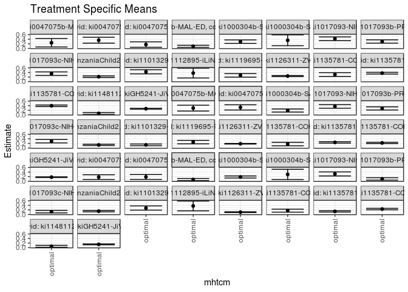

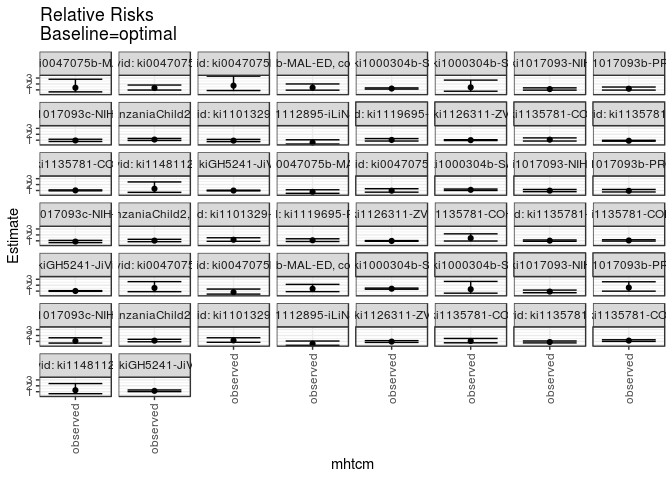

## Results Table

### Parameter: TSM

| agecat | studyid | country | intervention_level | baseline_level | estimate | ci_lower | ci_upper |
| --- | --- | --- | --- | --- | --- | --- | --- |
| 0-24 months | ki0047075b-MAL-ED | BANGLADESH | optimal | NA | 0.2458418 | 0.0611400 | 0.4305436 |
| 0-24 months | ki0047075b-MAL-ED | INDIA | optimal | NA | 0.3585607 | 0.2294030 | 0.4877184 |
| 0-24 months | ki0047075b-MAL-ED | NEPAL | optimal | NA | 0.1687993 | 0.0508210 | 0.2867775 |
| 0-24 months | ki0047075b-MAL-ED | TANZANIA, UNITED REPUBLIC OF | optimal | NA | 0.0909205 | 0.0451634 | 0.1366776 |
| 0-24 months | ki1000304b-SAS-CompFeed | INDIA | optimal | NA | 0.2943775 | 0.2179395 | 0.3708156 |
| 0-24 months | ki1000304b-SAS-FoodSuppl | INDIA | optimal | NA | 0.3537962 | 0.1173275 | 0.5902650 |
| 0-24 months | ki1017093-NIH-Birth | BANGLADESH | optimal | NA | 0.4221190 | 0.3416179 | 0.5026201 |
| 0-24 months | ki1017093b-PROVIDE | BANGLADESH | optimal | NA | 0.3014942 | 0.2298266 | 0.3731618 |
| 0-24 months | ki1017093c-NIH-Crypto | BANGLADESH | optimal | NA | 0.3474922 | 0.2695817 | 0.4254027 |
| 0-24 months | ki1066203-TanzaniaChild2 | TANZANIA, UNITED REPUBLIC OF | optimal | NA | 0.2140304 | 0.1777430 | 0.2503179 |
| 0-24 months | ki1101329-Keneba | GAMBIA | optimal | NA | 0.4288597 | 0.3384577 | 0.5192617 |
| 0-24 months | ki1112895-iLiNS-Zinc | BURKINA FASO | optimal | NA | 0.3724463 | 0.1575682 | 0.5873245 |
| 0-24 months | ki1119695-PROBIT | BELARUS | optimal | NA | 0.2762374 | 0.1975603 | 0.3549145 |
| 0-24 months | ki1126311-ZVITAMBO | ZIMBABWE | optimal | NA | 0.2433398 | 0.2231957 | 0.2634838 |
| 0-24 months | ki1135781-COHORTS | GUATEMALA | optimal | NA | 0.3084329 | 0.2266425 | 0.3902233 |
| 0-24 months | ki1135781-COHORTS | INDIA | optimal | NA | 0.3703733 | 0.3318790 | 0.4088676 |
| 0-24 months | ki1135781-COHORTS | PHILIPPINES | optimal | NA | 0.3965194 | 0.3622435 | 0.4307953 |
| 0-24 months | ki1148112-LCNI-5 | MALAWI | optimal | NA | 0.0608017 | 0.0195711 | 0.1020323 |
| 0-24 months | kiGH5241-JiVitA-3 | BANGLADESH | optimal | NA | 0.2667300 | 0.2484115 | 0.2850485 |
| 0-6 months | ki0047075b-MAL-ED | BANGLADESH | optimal | NA | 0.2937410 | 0.1654445 | 0.4220375 |
| 0-6 months | ki0047075b-MAL-ED | INDIA | optimal | NA | 0.3249637 | 0.2101706 | 0.4397568 |
| 0-6 months | ki1000304b-SAS-CompFeed | INDIA | optimal | NA | 0.1872293 | 0.1206957 | 0.2537629 |
| 0-6 months | ki1017093-NIH-Birth | BANGLADESH | optimal | NA | 0.3681978 | 0.2886291 | 0.4477665 |
| 0-6 months | ki1017093b-PROVIDE | BANGLADESH | optimal | NA | 0.2800172 | 0.2104726 | 0.3495618 |
| 0-6 months | ki1017093c-NIH-Crypto | BANGLADESH | optimal | NA | 0.2990485 | 0.2247818 | 0.3733153 |
| 0-6 months | ki1066203-TanzaniaChild2 | TANZANIA, UNITED REPUBLIC OF | optimal | NA | 0.1354529 | 0.1056841 | 0.1652218 |
| 0-6 months | ki1101329-Keneba | GAMBIA | optimal | NA | 0.1380196 | 0.0999578 | 0.1760813 |
| 0-6 months | ki1119695-PROBIT | BELARUS | optimal | NA | 0.2597697 | 0.1830543 | 0.3364850 |
| 0-6 months | ki1126311-ZVITAMBO | ZIMBABWE | optimal | NA | 0.1869079 | 0.1724562 | 0.2013595 |
| 0-6 months | ki1135781-COHORTS | GUATEMALA | optimal | NA | 0.1732372 | 0.0962808 | 0.2501936 |
| 0-6 months | ki1135781-COHORTS | INDIA | optimal | NA | 0.2469302 | 0.2144655 | 0.2793950 |
| 0-6 months | ki1135781-COHORTS | PHILIPPINES | optimal | NA | 0.2232752 | 0.1954700 | 0.2510804 |
| 0-6 months | kiGH5241-JiVitA-3 | BANGLADESH | optimal | NA | 0.1788690 | 0.1651470 | 0.1925911 |
| 6-24 months | ki0047075b-MAL-ED | INDIA | optimal | NA | 0.1784036 | 0.0748944 | 0.2819128 |
| 6-24 months | ki0047075b-MAL-ED | NEPAL | optimal | NA | 0.1885787 | 0.0784734 | 0.2986840 |
| 6-24 months | ki0047075b-MAL-ED | TANZANIA, UNITED REPUBLIC OF | optimal | NA | 0.0760855 | 0.0329713 | 0.1191997 |
| 6-24 months | ki1000304b-SAS-CompFeed | INDIA | optimal | NA | 0.1860607 | 0.1416751 | 0.2304463 |
| 6-24 months | ki1000304b-SAS-FoodSuppl | INDIA | optimal | NA | 0.2985560 | 0.0738815 | 0.5232305 |
| 6-24 months | ki1017093-NIH-Birth | BANGLADESH | optimal | NA | 0.3198639 | 0.2305151 | 0.4092127 |
| 6-24 months | ki1017093b-PROVIDE | BANGLADESH | optimal | NA | 0.1011753 | 0.0488271 | 0.1535234 |
| 6-24 months | ki1017093c-NIH-Crypto | BANGLADESH | optimal | NA | 0.1222120 | 0.0673723 | 0.1770517 |
| 6-24 months | ki1066203-TanzaniaChild2 | TANZANIA, UNITED REPUBLIC OF | optimal | NA | 0.1431531 | 0.1127088 | 0.1735973 |
| 6-24 months | ki1101329-Keneba | GAMBIA | optimal | NA | 0.2811711 | 0.1886585 | 0.3736837 |
| 6-24 months | ki1112895-iLiNS-Zinc | BURKINA FASO | optimal | NA | 0.3724463 | 0.1575682 | 0.5873245 |
| 6-24 months | ki1126311-ZVITAMBO | ZIMBABWE | optimal | NA | 0.0997933 | 0.0826954 | 0.1168912 |
| 6-24 months | ki1135781-COHORTS | GUATEMALA | optimal | NA | 0.1678889 | 0.1022369 | 0.2335409 |
| 6-24 months | ki1135781-COHORTS | INDIA | optimal | NA | 0.1337717 | 0.1057147 | 0.1618287 |
| 6-24 months | ki1135781-COHORTS | PHILIPPINES | optimal | NA | 0.2354187 | 0.2029171 | 0.2679204 |
| 6-24 months | ki1148112-LCNI-5 | MALAWI | optimal | NA | 0.0609277 | 0.0192882 | 0.1025672 |
| 6-24 months | kiGH5241-JiVitA-3 | BANGLADESH | optimal | NA | 0.1436138 | 0.1246619 | 0.1625656 |

### Parameter: E(Y)

| agecat | studyid | country | intervention_level | baseline_level | estimate | ci_lower | ci_upper |
| --- | --- | --- | --- | --- | --- | --- | --- |
| 0-24 months | ki0047075b-MAL-ED | BANGLADESH | observed | NA | 0.3346457 | 0.2765014 | 0.3927899 |
| 0-24 months | ki0047075b-MAL-ED | INDIA | observed | NA | 0.4752066 | 0.4121581 | 0.5382551 |
| 0-24 months | ki0047075b-MAL-ED | NEPAL | observed | NA | 0.2899160 | 0.2321510 | 0.3476810 |
| 0-24 months | ki0047075b-MAL-ED | TANZANIA, UNITED REPUBLIC OF | observed | NA | 0.1250000 | 0.0844083 | 0.1655917 |
| 0-24 months | ki1000304b-SAS-CompFeed | INDIA | observed | NA | 0.3609756 | 0.2943508 | 0.4276005 |
| 0-24 months | ki1000304b-SAS-FoodSuppl | INDIA | observed | NA | 0.5048544 | 0.4078263 | 0.6018825 |
| 0-24 months | ki1017093-NIH-Birth | BANGLADESH | observed | NA | 0.4775641 | 0.4383415 | 0.5167867 |
| 0-24 months | ki1017093b-PROVIDE | BANGLADESH | observed | NA | 0.3602392 | 0.3238339 | 0.3966444 |
| 0-24 months | ki1017093c-NIH-Crypto | BANGLADESH | observed | NA | 0.3311258 | 0.2975342 | 0.3647175 |
| 0-24 months | ki1066203-TanzaniaChild2 | TANZANIA, UNITED REPUBLIC OF | observed | NA | 0.2369648 | 0.2198019 | 0.2541277 |
| 0-24 months | ki1101329-Keneba | GAMBIA | observed | NA | 0.3958076 | 0.3763721 | 0.4152432 |
| 0-24 months | ki1112895-iLiNS-Zinc | BURKINA FASO | observed | NA | 0.2259307 | 0.1907517 | 0.2611097 |
| 0-24 months | ki1119695-PROBIT | BELARUS | observed | NA | 0.2876344 | 0.1859286 | 0.3893402 |
| 0-24 months | ki1126311-ZVITAMBO | ZIMBABWE | observed | NA | 0.2447609 | 0.2362612 | 0.2532607 |
| 0-24 months | ki1135781-COHORTS | GUATEMALA | observed | NA | 0.3354943 | 0.2982080 | 0.3727807 |
| 0-24 months | ki1135781-COHORTS | INDIA | observed | NA | 0.3338583 | 0.3126757 | 0.3550409 |
| 0-24 months | ki1135781-COHORTS | PHILIPPINES | observed | NA | 0.4036125 | 0.3861835 | 0.4210415 |
| 0-24 months | ki1148112-LCNI-5 | MALAWI | observed | NA | 0.0788530 | 0.0605839 | 0.0971222 |
| 0-24 months | kiGH5241-JiVitA-3 | BANGLADESH | observed | NA | 0.2641979 | 0.2551066 | 0.2732892 |
| 0-6 months | ki0047075b-MAL-ED | BANGLADESH | observed | NA | 0.2244094 | 0.1730022 | 0.2758167 |
| 0-6 months | ki0047075b-MAL-ED | INDIA | observed | NA | 0.3140496 | 0.2554513 | 0.3726479 |
| 0-6 months | ki1000304b-SAS-CompFeed | INDIA | observed | NA | 0.2078240 | 0.1493922 | 0.2662557 |
| 0-6 months | ki1017093-NIH-Birth | BANGLADESH | observed | NA | 0.3569132 | 0.3192325 | 0.3945938 |
| 0-6 months | ki1017093b-PROVIDE | BANGLADESH | observed | NA | 0.2630792 | 0.2296894 | 0.2964690 |
| 0-6 months | ki1017093c-NIH-Crypto | BANGLADESH | observed | NA | 0.2582781 | 0.2270370 | 0.2895193 |
| 0-6 months | ki1066203-TanzaniaChild2 | TANZANIA, UNITED REPUBLIC OF | observed | NA | 0.1394659 | 0.1254831 | 0.1534487 |
| 0-6 months | ki1101329-Keneba | GAMBIA | observed | NA | 0.1622128 | 0.1465647 | 0.1778610 |
| 0-6 months | ki1119695-PROBIT | BELARUS | observed | NA | 0.2824074 | 0.1800545 | 0.3847603 |
| 0-6 months | ki1126311-ZVITAMBO | ZIMBABWE | observed | NA | 0.1822082 | 0.1745617 | 0.1898546 |
| 0-6 months | ki1135781-COHORTS | GUATEMALA | observed | NA | 0.2505010 | 0.2124450 | 0.2885570 |
| 0-6 months | ki1135781-COHORTS | INDIA | observed | NA | 0.2528180 | 0.2330767 | 0.2725593 |
| 0-6 months | ki1135781-COHORTS | PHILIPPINES | observed | NA | 0.2355453 | 0.2204685 | 0.2506222 |
| 0-6 months | kiGH5241-JiVitA-3 | BANGLADESH | observed | NA | 0.1822104 | 0.1742135 | 0.1902074 |
| 6-24 months | ki0047075b-MAL-ED | INDIA | observed | NA | 0.2735043 | 0.2162683 | 0.3307402 |
| 6-24 months | ki0047075b-MAL-ED | NEPAL | observed | NA | 0.1531915 | 0.1070438 | 0.1993392 |
| 6-24 months | ki0047075b-MAL-ED | TANZANIA, UNITED REPUBLIC OF | observed | NA | 0.1061224 | 0.0674772 | 0.1447677 |
| 6-24 months | ki1000304b-SAS-CompFeed | INDIA | observed | NA | 0.2617801 | 0.2144185 | 0.3091417 |
| 6-24 months | ki1000304b-SAS-FoodSuppl | INDIA | observed | NA | 0.3921569 | 0.2969402 | 0.4873736 |
| 6-24 months | ki1017093-NIH-Birth | BANGLADESH | observed | NA | 0.2939002 | 0.2554778 | 0.3323226 |
| 6-24 months | ki1017093b-PROVIDE | BANGLADESH | observed | NA | 0.1612378 | 0.1321259 | 0.1903497 |
| 6-24 months | ki1017093c-NIH-Crypto | BANGLADESH | observed | NA | 0.1315068 | 0.1069744 | 0.1560393 |
| 6-24 months | ki1066203-TanzaniaChild2 | TANZANIA, UNITED REPUBLIC OF | observed | NA | 0.1617128 | 0.1455117 | 0.1779140 |
| 6-24 months | ki1101329-Keneba | GAMBIA | observed | NA | 0.3288908 | 0.3097941 | 0.3479875 |
| 6-24 months | ki1112895-iLiNS-Zinc | BURKINA FASO | observed | NA | 0.2259307 | 0.1907517 | 0.2611097 |
| 6-24 months | ki1126311-ZVITAMBO | ZIMBABWE | observed | NA | 0.0964361 | 0.0901919 | 0.1026803 |
| 6-24 months | ki1135781-COHORTS | GUATEMALA | observed | NA | 0.1797153 | 0.1479435 | 0.2114871 |
| 6-24 months | ki1135781-COHORTS | INDIA | observed | NA | 0.1199132 | 0.1050778 | 0.1347486 |
| 6-24 months | ki1135781-COHORTS | PHILIPPINES | observed | NA | 0.2666429 | 0.2502871 | 0.2829988 |
| 6-24 months | ki1148112-LCNI-5 | MALAWI | observed | NA | 0.0765492 | 0.0583736 | 0.0947248 |
| 6-24 months | kiGH5241-JiVitA-3 | BANGLADESH | observed | NA | 0.1647321 | 0.1555996 | 0.1738646 |

### Parameter: RR

| agecat | studyid | country | intervention_level | baseline_level | estimate | ci_lower | ci_upper |
| --- | --- | --- | --- | --- | --- | --- | --- |
| 0-24 months | ki0047075b-MAL-ED | BANGLADESH | observed | optimal | 1.3612238 | 0.6613414 | 2.8017755 |
| 0-24 months | ki0047075b-MAL-ED | INDIA | observed | optimal | 1.3253170 | 0.9663445 | 1.8176388 |
| 0-24 months | ki0047075b-MAL-ED | NEPAL | observed | optimal | 1.7175193 | 0.8898652 | 3.3149653 |
| 0-24 months | ki0047075b-MAL-ED | TANZANIA, UNITED REPUBLIC OF | observed | optimal | 1.3748271 | 0.9473527 | 1.9951909 |
| 0-24 months | ki1000304b-SAS-CompFeed | INDIA | observed | optimal | 1.2262337 | 1.1294033 | 1.3313659 |
| 0-24 months | ki1000304b-SAS-FoodSuppl | INDIA | observed | optimal | 1.4269637 | 0.7676758 | 2.6524549 |
| 0-24 months | ki1017093-NIH-Birth | BANGLADESH | observed | optimal | 1.1313494 | 0.9565294 | 1.3381203 |
| 0-24 months | ki1017093b-PROVIDE | BANGLADESH | observed | optimal | 1.1948462 | 0.9649290 | 1.4795465 |
| 0-24 months | ki1017093c-NIH-Crypto | BANGLADESH | observed | optimal | 0.9529014 | 0.7807440 | 1.1630202 |
| 0-24 months | ki1066203-TanzaniaChild2 | TANZANIA, UNITED REPUBLIC OF | observed | optimal | 1.1071548 | 0.9516700 | 1.2880429 |
| 0-24 months | ki1101329-Keneba | GAMBIA | observed | optimal | 0.9229303 | 0.7521416 | 1.1324999 |
| 0-24 months | ki1112895-iLiNS-Zinc | BURKINA FASO | observed | optimal | 0.6066127 | 0.3451603 | 1.0661103 |
| 0-24 months | ki1119695-PROBIT | BELARUS | observed | optimal | 1.0412581 | 0.8544467 | 1.2689128 |
| 0-24 months | ki1126311-ZVITAMBO | ZIMBABWE | observed | optimal | 1.0058403 | 0.9333288 | 1.0839853 |
| 0-24 months | ki1135781-COHORTS | GUATEMALA | observed | optimal | 1.0877386 | 0.8553672 | 1.3832367 |
| 0-24 months | ki1135781-COHORTS | INDIA | observed | optimal | 0.9014102 | 0.8284397 | 0.9808081 |
| 0-24 months | ki1135781-COHORTS | PHILIPPINES | observed | optimal | 1.0178885 | 0.9443341 | 1.0971719 |
| 0-24 months | ki1148112-LCNI-5 | MALAWI | observed | optimal | 1.2968888 | 0.6872337 | 2.4473779 |
| 0-24 months | kiGH5241-JiVitA-3 | BANGLADESH | observed | optimal | 0.9905069 | 0.9344137 | 1.0499674 |
| 0-6 months | ki0047075b-MAL-ED | BANGLADESH | observed | optimal | 0.7639704 | 0.5203616 | 1.1216254 |
| 0-6 months | ki0047075b-MAL-ED | INDIA | observed | optimal | 0.9664144 | 0.7199447 | 1.2972618 |
| 0-6 months | ki1000304b-SAS-CompFeed | INDIA | observed | optimal | 1.1099968 | 0.9946669 | 1.2386989 |
| 0-6 months | ki1017093-NIH-Birth | BANGLADESH | observed | optimal | 0.9693518 | 0.8008071 | 1.1733698 |
| 0-6 months | ki1017093b-PROVIDE | BANGLADESH | observed | optimal | 0.9395110 | 0.7524007 | 1.1731526 |
| 0-6 months | ki1017093c-NIH-Crypto | BANGLADESH | observed | optimal | 0.8636663 | 0.6939220 | 1.0749327 |
| 0-6 months | ki1066203-TanzaniaChild2 | TANZANIA, UNITED REPUBLIC OF | observed | optimal | 1.0296261 | 0.8460263 | 1.2530696 |
| 0-6 months | ki1101329-Keneba | GAMBIA | observed | optimal | 1.1752886 | 0.9119260 | 1.5147099 |
| 0-6 months | ki1119695-PROBIT | BELARUS | observed | optimal | 1.0871455 | 0.8839275 | 1.3370840 |
| 0-6 months | ki1126311-ZVITAMBO | ZIMBABWE | observed | optimal | 0.9748555 | 0.9136958 | 1.0401089 |
| 0-6 months | ki1135781-COHORTS | GUATEMALA | observed | optimal | 1.4460001 | 0.9586816 | 2.1810329 |
| 0-6 months | ki1135781-COHORTS | INDIA | observed | optimal | 1.0238440 | 0.9186151 | 1.1411270 |
| 0-6 months | ki1135781-COHORTS | PHILIPPINES | observed | optimal | 1.0549553 | 0.9487648 | 1.1730312 |
| 0-6 months | kiGH5241-JiVitA-3 | BANGLADESH | observed | optimal | 1.0186809 | 0.9581899 | 1.0829907 |
| 6-24 months | ki0047075b-MAL-ED | INDIA | observed | optimal | 1.5330647 | 0.9042775 | 2.5990776 |
| 6-24 months | ki0047075b-MAL-ED | NEPAL | observed | optimal | 0.8123478 | 0.4903897 | 1.3456826 |
| 6-24 months | ki0047075b-MAL-ED | TANZANIA, UNITED REPUBLIC OF | observed | optimal | 1.3947784 | 0.9114711 | 2.1343593 |
| 6-24 months | ki1000304b-SAS-CompFeed | INDIA | observed | optimal | 1.4069608 | 1.3170294 | 1.5030330 |
| 6-24 months | ki1000304b-SAS-FoodSuppl | INDIA | observed | optimal | 1.3135119 | 0.6537916 | 2.6389349 |
| 6-24 months | ki1017093-NIH-Birth | BANGLADESH | observed | optimal | 0.9188289 | 0.7225893 | 1.1683630 |
| 6-24 months | ki1017093b-PROVIDE | BANGLADESH | observed | optimal | 1.5936481 | 0.9860177 | 2.5757289 |
| 6-24 months | ki1017093c-NIH-Crypto | BANGLADESH | observed | optimal | 1.0760550 | 0.7180622 | 1.6125267 |
| 6-24 months | ki1066203-TanzaniaChild2 | TANZANIA, UNITED REPUBLIC OF | observed | optimal | 1.1296499 | 0.9388413 | 1.3592382 |
| 6-24 months | ki1101329-Keneba | GAMBIA | observed | optimal | 1.1697176 | 0.8467688 | 1.6158358 |
| 6-24 months | ki1112895-iLiNS-Zinc | BURKINA FASO | observed | optimal | 0.6066127 | 0.3451603 | 1.0661103 |
| 6-24 months | ki1126311-ZVITAMBO | ZIMBABWE | observed | optimal | 0.9663582 | 0.8237547 | 1.1336483 |
| 6-24 months | ki1135781-COHORTS | GUATEMALA | observed | optimal | 1.0704416 | 0.7647614 | 1.4983042 |
| 6-24 months | ki1135781-COHORTS | INDIA | observed | optimal | 0.8964017 | 0.7513635 | 1.0694372 |
| 6-24 months | ki1135781-COHORTS | PHILIPPINES | observed | optimal | 1.1326326 | 1.0031761 | 1.2787950 |
| 6-24 months | ki1148112-LCNI-5 | MALAWI | observed | optimal | 1.2563938 | 0.6637386 | 2.3782335 |
| 6-24 months | kiGH5241-JiVitA-3 | BANGLADESH | observed | optimal | 1.1470495 | 1.0178458 | 1.2926540 |

### Parameter: PAR

| agecat | studyid | country | intervention_level | baseline_level | estimate | ci_lower | ci_upper |
| --- | --- | --- | --- | --- | --- | --- | --- |
| 0-24 months | ki0047075b-MAL-ED | BANGLADESH | optimal | NA | 0.0888039 | -0.0885221 | 0.2661299 |
| 0-24 months | ki0047075b-MAL-ED | INDIA | optimal | NA | 0.1166459 | 0.0046138 | 0.2286780 |
| 0-24 months | ki0047075b-MAL-ED | NEPAL | optimal | NA | 0.1211167 | 0.0090131 | 0.2332203 |
| 0-24 months | ki0047075b-MAL-ED | TANZANIA, UNITED REPUBLIC OF | optimal | NA | 0.0340795 | -0.0011436 | 0.0693025 |
| 0-24 months | ki1000304b-SAS-CompFeed | INDIA | optimal | NA | 0.0665981 | 0.0518967 | 0.0812995 |
| 0-24 months | ki1000304b-SAS-FoodSuppl | INDIA | optimal | NA | 0.1510582 | -0.0670885 | 0.3692048 |
| 0-24 months | ki1017093-NIH-Birth | BANGLADESH | optimal | NA | 0.0554451 | -0.0153167 | 0.1262068 |
| 0-24 months | ki1017093b-PROVIDE | BANGLADESH | optimal | NA | 0.0587450 | -0.0058783 | 0.1233682 |
| 0-24 months | ki1017093c-NIH-Crypto | BANGLADESH | optimal | NA | -0.0163664 | -0.0856402 | 0.0529074 |
| 0-24 months | ki1066203-TanzaniaChild2 | TANZANIA, UNITED REPUBLIC OF | optimal | NA | 0.0229344 | -0.0094522 | 0.0553210 |
| 0-24 months | ki1101329-Keneba | GAMBIA | optimal | NA | -0.0330521 | -0.1208364 | 0.0547323 |
| 0-24 months | ki1112895-iLiNS-Zinc | BURKINA FASO | optimal | NA | -0.1465157 | -0.3565556 | 0.0635242 |
| 0-24 months | ki1119695-PROBIT | BELARUS | optimal | NA | 0.0113970 | -0.0457080 | 0.0685020 |
| 0-24 months | ki1126311-ZVITAMBO | ZIMBABWE | optimal | NA | 0.0014212 | -0.0167854 | 0.0196277 |
| 0-24 months | ki1135781-COHORTS | GUATEMALA | optimal | NA | 0.0270615 | -0.0471118 | 0.1012347 |
| 0-24 months | ki1135781-COHORTS | INDIA | optimal | NA | -0.0365150 | -0.0677908 | -0.0052392 |
| 0-24 months | ki1135781-COHORTS | PHILIPPINES | optimal | NA | 0.0070931 | -0.0226505 | 0.0368367 |
| 0-24 months | ki1148112-LCNI-5 | MALAWI | optimal | NA | 0.0180513 | -0.0207459 | 0.0568486 |
| 0-24 months | kiGH5241-JiVitA-3 | BANGLADESH | optimal | NA | -0.0025321 | -0.0180850 | 0.0130208 |
| 0-6 months | ki0047075b-MAL-ED | BANGLADESH | optimal | NA | -0.0693316 | -0.1824195 | 0.0437563 |
| 0-6 months | ki0047075b-MAL-ED | INDIA | optimal | NA | -0.0109141 | -0.1066719 | 0.0848437 |
| 0-6 months | ki1000304b-SAS-CompFeed | INDIA | optimal | NA | 0.0205946 | 0.0027142 | 0.0384751 |
| 0-6 months | ki1017093-NIH-Birth | BANGLADESH | optimal | NA | -0.0112846 | -0.0815958 | 0.0590266 |
| 0-6 months | ki1017093b-PROVIDE | BANGLADESH | optimal | NA | -0.0169380 | -0.0790211 | 0.0451452 |
| 0-6 months | ki1017093c-NIH-Crypto | BANGLADESH | optimal | NA | -0.0407704 | -0.1063176 | 0.0247768 |
| 0-6 months | ki1066203-TanzaniaChild2 | TANZANIA, UNITED REPUBLIC OF | optimal | NA | 0.0040129 | -0.0225964 | 0.0306223 |
| 0-6 months | ki1101329-Keneba | GAMBIA | optimal | NA | 0.0241933 | -0.0107882 | 0.0591748 |
| 0-6 months | ki1119695-PROBIT | BELARUS | optimal | NA | 0.0226378 | -0.0362552 | 0.0815307 |
| 0-6 months | ki1126311-ZVITAMBO | ZIMBABWE | optimal | NA | -0.0046997 | -0.0168121 | 0.0074126 |
| 0-6 months | ki1135781-COHORTS | GUATEMALA | optimal | NA | 0.0772638 | 0.0055995 | 0.1489282 |
| 0-6 months | ki1135781-COHORTS | INDIA | optimal | NA | 0.0058878 | -0.0209118 | 0.0326875 |
| 0-6 months | ki1135781-COHORTS | PHILIPPINES | optimal | NA | 0.0122702 | -0.0114217 | 0.0359621 |
| 0-6 months | kiGH5241-JiVitA-3 | BANGLADESH | optimal | NA | 0.0033414 | -0.0076038 | 0.0142866 |
| 6-24 months | ki0047075b-MAL-ED | INDIA | optimal | NA | 0.0951007 | 0.0001007 | 0.1901007 |
| 6-24 months | ki0047075b-MAL-ED | NEPAL | optimal | NA | -0.0353872 | -0.1310031 | 0.0602287 |
| 6-24 months | ki0047075b-MAL-ED | TANZANIA, UNITED REPUBLIC OF | optimal | NA | 0.0300369 | -0.0038788 | 0.0639526 |
| 6-24 months | ki1000304b-SAS-CompFeed | INDIA | optimal | NA | 0.0757194 | 0.0680005 | 0.0834383 |
| 6-24 months | ki1000304b-SAS-FoodSuppl | INDIA | optimal | NA | 0.0936009 | -0.1145500 | 0.3017517 |
| 6-24 months | ki1017093-NIH-Birth | BANGLADESH | optimal | NA | -0.0259637 | -0.1030620 | 0.0511346 |
| 6-24 months | ki1017093b-PROVIDE | BANGLADESH | optimal | NA | 0.0600625 | 0.0105735 | 0.1095515 |
| 6-24 months | ki1017093c-NIH-Crypto | BANGLADESH | optimal | NA | 0.0092948 | -0.0401367 | 0.0587264 |
| 6-24 months | ki1066203-TanzaniaChild2 | TANZANIA, UNITED REPUBLIC OF | optimal | NA | 0.0185598 | -0.0079430 | 0.0450626 |
| 6-24 months | ki1101329-Keneba | GAMBIA | optimal | NA | 0.0477197 | -0.0431292 | 0.1385686 |
| 6-24 months | ki1112895-iLiNS-Zinc | BURKINA FASO | optimal | NA | -0.1465157 | -0.3565556 | 0.0635242 |
| 6-24 months | ki1126311-ZVITAMBO | ZIMBABWE | optimal | NA | -0.0033572 | -0.0192884 | 0.0125740 |
| 6-24 months | ki1135781-COHORTS | GUATEMALA | optimal | NA | 0.0118264 | -0.0445160 | 0.0681687 |
| 6-24 months | ki1135781-COHORTS | INDIA | optimal | NA | -0.0138585 | -0.0374344 | 0.0097174 |
| 6-24 months | ki1135781-COHORTS | PHILIPPINES | optimal | NA | 0.0312242 | 0.0026592 | 0.0597892 |
| 6-24 months | ki1148112-LCNI-5 | MALAWI | optimal | NA | 0.0156215 | -0.0233910 | 0.0546340 |
| 6-24 months | kiGH5241-JiVitA-3 | BANGLADESH | optimal | NA | 0.0211183 | 0.0039212 | 0.0383154 |

### Parameter: PAF

| agecat | studyid | country | intervention_level | baseline_level | estimate | ci_lower | ci_upper |
| --- | --- | --- | --- | --- | --- | --- | --- |
| 0-24 months | ki0047075b-MAL-ED | BANGLADESH | optimal | NA | 0.2653669 | -0.5120783 | 0.6430835 |
| 0-24 months | ki0047075b-MAL-ED | INDIA | optimal | NA | 0.2454636 | -0.0348277 | 0.4498357 |
| 0-24 months | ki0047075b-MAL-ED | NEPAL | optimal | NA | 0.4177649 | -0.1237657 | 0.6983377 |
| 0-24 months | ki0047075b-MAL-ED | TANZANIA, UNITED REPUBLIC OF | optimal | NA | 0.2726358 | -0.0555730 | 0.4987948 |
| 0-24 months | ki1000304b-SAS-CompFeed | INDIA | optimal | NA | 0.1844947 | 0.1145767 | 0.2488917 |
| 0-24 months | ki1000304b-SAS-FoodSuppl | INDIA | optimal | NA | 0.2992113 | -0.3026331 | 0.6229908 |
| 0-24 months | ki1017093-NIH-Birth | BANGLADESH | optimal | NA | 0.1160997 | -0.0454462 | 0.2526830 |
| 0-24 months | ki1017093b-PROVIDE | BANGLADESH | optimal | NA | 0.1630722 | -0.0363457 | 0.3241172 |
| 0-24 months | ki1017093c-NIH-Crypto | BANGLADESH | optimal | NA | -0.0494266 | -0.2808296 | 0.1401697 |
| 0-24 months | ki1066203-TanzaniaChild2 | TANZANIA, UNITED REPUBLIC OF | optimal | NA | 0.0967840 | -0.0507844 | 0.2236283 |
| 0-24 months | ki1101329-Keneba | GAMBIA | optimal | NA | -0.0835054 | -0.3295368 | 0.1169977 |
| 0-24 months | ki1112895-iLiNS-Zinc | BURKINA FASO | optimal | NA | -0.6484983 | -1.8972043 | 0.0620107 |
| 0-24 months | ki1119695-PROBIT | BELARUS | optimal | NA | 0.0396233 | -0.1703480 | 0.2119238 |
| 0-24 months | ki1126311-ZVITAMBO | ZIMBABWE | optimal | NA | 0.0058064 | -0.0714337 | 0.0774783 |
| 0-24 months | ki1135781-COHORTS | GUATEMALA | optimal | NA | 0.0806615 | -0.1690886 | 0.2770579 |
| 0-24 months | ki1135781-COHORTS | INDIA | optimal | NA | -0.1093728 | -0.2070884 | -0.0195674 |
| 0-24 months | ki1135781-COHORTS | PHILIPPINES | optimal | NA | 0.0175741 | -0.0589472 | 0.0885658 |
| 0-24 months | ki1148112-LCNI-5 | MALAWI | optimal | NA | 0.2289238 | -0.4551092 | 0.5913994 |
| 0-24 months | kiGH5241-JiVitA-3 | BANGLADESH | optimal | NA | -0.0095841 | -0.0701898 | 0.0475894 |
| 0-6 months | ki0047075b-MAL-ED | BANGLADESH | optimal | NA | -0.3089512 | -0.9217405 | 0.1084367 |
| 0-6 months | ki0047075b-MAL-ED | INDIA | optimal | NA | -0.0347528 | -0.3889955 | 0.2291456 |
| 0-6 months | ki1000304b-SAS-CompFeed | INDIA | optimal | NA | 0.0990965 | -0.0053617 | 0.1927013 |
| 0-6 months | ki1017093-NIH-Birth | BANGLADESH | optimal | NA | -0.0316172 | -0.2487402 | 0.1477538 |
| 0-6 months | ki1017093b-PROVIDE | BANGLADESH | optimal | NA | -0.0643835 | -0.3290790 | 0.1475960 |
| 0-6 months | ki1017093c-NIH-Crypto | BANGLADESH | optimal | NA | -0.1578546 | -0.4410841 | 0.0697092 |
| 0-6 months | ki1066203-TanzaniaChild2 | TANZANIA, UNITED REPUBLIC OF | optimal | NA | 0.0287737 | -0.1819963 | 0.2019598 |
| 0-6 months | ki1101329-Keneba | GAMBIA | optimal | NA | 0.1491452 | -0.0965802 | 0.3398076 |
| 0-6 months | ki1119695-PROBIT | BELARUS | optimal | NA | 0.0801599 | -0.1313145 | 0.2521038 |
| 0-6 months | ki1126311-ZVITAMBO | ZIMBABWE | optimal | NA | -0.0257931 | -0.0944561 | 0.0385622 |
| 0-6 months | ki1135781-COHORTS | GUATEMALA | optimal | NA | 0.3084371 | -0.0430992 | 0.5415016 |
| 0-6 months | ki1135781-COHORTS | INDIA | optimal | NA | 0.0232887 | -0.0885952 | 0.1236734 |
| 0-6 months | ki1135781-COHORTS | PHILIPPINES | optimal | NA | 0.0520926 | -0.0540020 | 0.1475078 |
| 0-6 months | kiGH5241-JiVitA-3 | BANGLADESH | optimal | NA | 0.0183383 | -0.0436345 | 0.0766310 |
| 6-24 months | ki0047075b-MAL-ED | INDIA | optimal | NA | 0.3477118 | -0.1058552 | 0.6152481 |
| 6-24 months | ki0047075b-MAL-ED | NEPAL | optimal | NA | -0.2309999 | -1.0391946 | 0.2568827 |
| 6-24 months | ki0047075b-MAL-ED | TANZANIA, UNITED REPUBLIC OF | optimal | NA | 0.2830402 | -0.0971275 | 0.5314753 |
| 6-24 months | ki1000304b-SAS-CompFeed | INDIA | optimal | NA | 0.2892481 | 0.2407155 | 0.3346786 |
| 6-24 months | ki1000304b-SAS-FoodSuppl | INDIA | optimal | NA | 0.2386822 | -0.5295394 | 0.6210592 |
| 6-24 months | ki1017093-NIH-Birth | BANGLADESH | optimal | NA | -0.0883419 | -0.3839120 | 0.1441016 |
| 6-24 months | ki1017093b-PROVIDE | BANGLADESH | optimal | NA | 0.3725089 | -0.0141806 | 0.6117604 |
| 6-24 months | ki1017093c-NIH-Crypto | BANGLADESH | optimal | NA | 0.0706795 | -0.3926370 | 0.3798552 |
| 6-24 months | ki1066203-TanzaniaChild2 | TANZANIA, UNITED REPUBLIC OF | optimal | NA | 0.1147700 | -0.0651428 | 0.2642938 |
| 6-24 months | ki1101329-Keneba | GAMBIA | optimal | NA | 0.1450928 | -0.1809599 | 0.3811253 |
| 6-24 months | ki1112895-iLiNS-Zinc | BURKINA FASO | optimal | NA | -0.6484983 | -1.8972043 | 0.0620107 |
| 6-24 months | ki1126311-ZVITAMBO | ZIMBABWE | optimal | NA | -0.0348130 | -0.2139537 | 0.1178922 |
| 6-24 months | ki1135781-COHORTS | GUATEMALA | optimal | NA | 0.0658062 | -0.3075973 | 0.3325788 |
| 6-24 months | ki1135781-COHORTS | INDIA | optimal | NA | -0.1155712 | -0.3309137 | 0.0649288 |
| 6-24 months | ki1135781-COHORTS | PHILIPPINES | optimal | NA | 0.1171012 | 0.0031660 | 0.2180139 |
| 6-24 months | ki1148112-LCNI-5 | MALAWI | optimal | NA | 0.2040712 | -0.5066171 | 0.5795198 |
| 6-24 months | kiGH5241-JiVitA-3 | BANGLADESH | optimal | NA | 0.1281980 | 0.0175329 | 0.2263978 |